# Hand Gesture Recognition

## Introduction

Hand gesture recognition is a critical component of human-computer interaction, enabling intuitive control of devices using natural hand movements. This project focuses on the development and evaluation of a Convolutional Neural Network (CNN) model for recognizing various hand gestures, utilizing a comprehensive dataset provided by the Universidad de Alicante. The dataset comprises real images, synthetic images, and scene descriptions, designed to train and evaluate hand gesture detection methods.

# Dataset Overview

The original images and videos were recorded at a resolution of 1,920 x 1,080 pixels. However, for performance and accuracy reasons, the images were scaled down to a spatial resolution of 224 x 224 pixels.

Dataset sources: https://www.dlsi.ua.es/~jgallego/datasets/gestures/

Gesture Categories and Dataset Summary The dataset encompasses the following gesture categories:

The dataset is highly suitable for training robust hand gesture recognition models due to its quality and diversity, as evidenced by several key factors:

[figure not shown]

# Project Objectives

## Imports Libraries

```python
import os
import cv2
import torch
import torchvision.transforms as transforms
from torch.utils.data import Dataset, DataLoader, random_split
import matplotlib.pyplot as plt
import random
import xml.etree.ElementTree as ET
from sklearn.model_selection import train_test_split
```

# Data Preprocessing

First I want to specify the set of labels (gestures) that the model will be trained to recognize and sets up the directory for accessing the images and their annotations.

```python
# Define the classes
labels_to_include = ['Drag', 'Loupe', 'Point', 'Scale', 'None']

# Define the paths
dataset_path = r'hand-detector\dataset'
annotation_path = os.path.join(dataset_path, 'annotations')
image_path = os.path.join(dataset_path, 'images')
```

Since the images and annotations are in a different folder, I need to combine both file. Also, I need to extract the relevant information from the annotation file such as the box x and y coordinates.

```python
def parse_annotation(annotation_file):
    tree = ET.parse(annotation_file)
    root = tree.getroot()
    bndboxes = []

    # Derive label from the annotation file path
    annotation_dir = os.path.dirname(annotation_file)
    label = os.path.basename(annotation_dir)

    if label not in labels_to_include:
        return None, None, None

    for obj in root.findall('object'):
        name = obj.find('name').text

        # Skip objects not in labels_to_include
        if name not in labels_to_include:
            continue

        bndbox = obj.find('bndbox')
        xmin = int(bndbox.find('xmin').text)
        ymin = int(bndbox.find('ymin').text)
        xmax = int(bndbox.find('xmax').text)
        ymax = int(bndbox.find('ymax').text)
        bndboxes.append((xmin, ymin, xmax, ymax))

    filename = root.find('filename').text
    return filename, bndboxes, label
```

Prepares the data for input into a neural network. This transformation pipeline converts images from their original format to PyTorch tensors and normalizes their pixel values. Normalization helps in faster convergence during training by ensuring the pixel values are within a specific range.

```python
transform = transforms.Compose([
    transforms.ToTensor(),  # Convert to tensor
    transforms.Normalize((0.5, 0.5, 0.5), (0.5, 0.5, 0.5))  # Normalize
])
```

## Data Preparation

Defines a dataset class that can be used with PyTorch's data loading utilities. Then images are resized to a standard size of 224x224 pixels, and optional transformations can be applied. The class handles cases where there are no annotations (e.g., 'None' class) by returning an empty list for bounding boxes.

```python
# Custom Dataset class
class CustomDataset(Dataset):
    def __init__(self, images, annotations, transform=None):
        self.images = images
        self.annotations = annotations
        self.transform = transform

    def __len__(self):
        return len(self.images)

    def __getitem__(self, idx):
        image = self.images[idx]
        annotation = self.annotations[idx]

        # If annotation is None (for 'None' class), set to empty list
        if annotation[1] is None:
            bndboxes = []
        else:
            bndboxes = annotation[1]

        image = cv2.resize(image, (224, 224))

        # Perform transformations if specified
        if self.transform:
            image = self.transform(image)

        return image, bndboxes, annotation[2]  # image, annotations, label
```

## Data Loading

```python
# Function to read and process images
def load_images_and_annotations():
    images = []
    annotations = []

    for label in labels_to_include:
        image_folder = os.path.join(image_path, label)

        if label == 'None':
            # For images in the None folder (no annotations)
            if os.path.exists(image_folder):
                for image_file in os.listdir(image_folder):
                    image_filepath = os.path.join(image_folder, image_file)
                    image = cv2.imread(image_filepath)
                    if image is not None:
                        images.append(image)
                        annotations.append((image_file, None, label))  # No annotations for None images
                    else:
                        print(f"Image not found or cannot be read: {image_filepath}")
            else:
                print(f"Image folder does not exist: {image_folder}")
        else:
            # For images with annotations
            annotation_folder = os.path.join(dataset_path, 'annotations', label)
            if os.path.exists(annotation_folder):
                for annotation_file in os.listdir(annotation_folder):
                    annotation_filepath = os.path.join(annotation_folder, annotation_file)
                    filename, _, _ = parse_annotation(annotation_filepath)
                    if filename:
                        image_filepath = os.path.join(image_folder, filename)
                        image = cv2.imread(image_filepath)
                        if image is not None:
                            images.append(image)
                            annotations.append((filename, None, label))  # No annotations for these images
                        else:
                            print(f"Image not found or cannot be read: {image_filepath}")
                    else:
                        print(f"Failed to parse annotation: {annotation_filepath}")
            else:
                print(f"Annotation path does not exist: {annotation_folder}")

    return images, annotations
```

## Data Exploratory

First I need to organize annotations into separate groups based on their labels. Then, I want to iterate through the annotations, and for each annotation, it adds it to the appropriate list in the dictionary based on its label.

```python
# Group annotations by class
def group_annotations_by_class(annotations):
    grouped_annotations = {label: [] for label in labels_to_include}
    for annotation in annotations:
        filename, bndboxes, label = annotation
        if label in grouped_annotations:
            grouped_annotations[label].append(annotation)
    return grouped_annotations
```

```python
# Function to plot random samples from each class
def plot_random_samples(images, annotations):
    grouped_annotations = group_annotations_by_class(annotations)
    fig, axes = plt.subplots(1, len(labels_to_include), figsize=(20, 5))
    for i, label in enumerate(labels_to_include):
        ax = axes[i]
        if label in grouped_annotations and len(grouped_annotations[label]) > 0:
            random_annotation = random.choice(grouped_annotations[label])
            filename, bndboxes, _ = random_annotation
            image_idx = [i for i, ann in enumerate(annotations) if ann == random_annotation][0]
            image = images[image_idx]
            if bndboxes is not None:
                for (xmin, ymin, xmax, ymax) in bndboxes:
                    cv2.rectangle(image, (xmin, ymin), (xmax, ymax), (255, 0, 0), 2)
            ax.imshow(cv2.cvtColor(image, cv2.COLOR_BGR2RGB))
            ax.set_title(label)
            ax.axis('off')
        else:
            ax.set_title(f'No {label}')
            ax.axis('off')
    plt.show()
```

```python
# transform = transforms.Compose([
#     transforms.ToTensor(),  # Convert to tensor
#     transforms.Normalize((0.5, 0.5, 0.5), (0.5, 0.5, 0.5))  # Normalize
# ])
```

Now I load the images and their annotations from the directory. Then the resulting images and annotations are stored in a list called images and annotations.

```python
images, annotations = load_images_and_annotations()
```

## Visualization

Now I want to get a random images and its label to proof that each images and its annotations are correctly loaded.

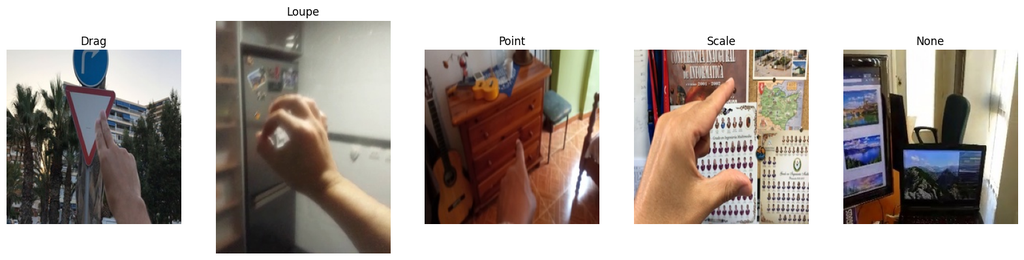

```python
plot_random_samples(images, annotations)
```

## Visualizes the distribution of images across different classes in the dataset.

I want to check the images distribution from each classes. The total distribution should be somewhat or close to equal. In this case, the data distribution are equally spreaded around 2000 images and annotation from each classes.

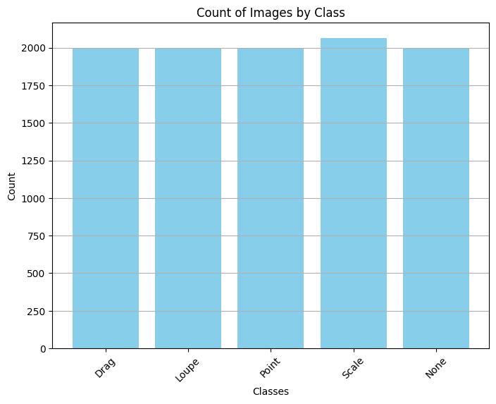

```python
# Function to plot the count of each class
def plot_class_counts(annotations):
    labels = [annotation[2] for annotation in annotations if annotation[2] in labels_to_include]
    label_counts = {label: labels.count(label) for label in labels_to_include}

    plt.figure(figsize=(8, 6))
    plt.bar(label_counts.keys(), label_counts.values(), color='skyblue')
    plt.xlabel('Classes')
    plt.ylabel('Count')
    plt.title('Count of Images by Class')
    plt.xticks(rotation=45)
    plt.grid(axis='y')

    plt.show()

plot_class_counts(annotations)
```

Now I want to load the images and annotations into one variable called `dataset`.

```python
dataset = CustomDataset(images, annotations, transform=transform)
```

# Data Splitting

The dataset (images and annotations) is split into training, validation, and test sets using train_test_split from sklearn. The distribution are 80%-10%-10% respectively.

```python
train_images, valtest_images, train_annotations, valtest_annotations = train_test_split(images, annotations, test_size=0.2, random_state=42)
val_images, test_images, val_annotations, test_annotations = train_test_split(valtest_images, valtest_annotations, test_size=0.5, random_state=42)
```

```python
# transform = transforms.Compose([
#     transforms.ToTensor(),  # Convert to tensor
#     transforms.Normalize((0.5, 0.5, 0.5), (0.5, 0.5, 0.5))  # Normalize
# ])
```

Now to train pytorch's neural network, I need to make pytorch's dataset and dataloder, to create pytorch's dataset objects (train_dataset, val_dataset, test_dataset) for training, validation, and testing respectively. The difference between dataset and dataloader is, dataset holds all the data you want to work with, while the dataloader helps manage and deliver that data in a structured manner to the machine learning model, making the learning process smoother and more efficient.

```python
# Create datasets
train_dataset = CustomDataset(train_images, train_annotations, transform=transform)
val_dataset = CustomDataset(val_images, val_annotations, transform=transform)
test_dataset = CustomDataset(test_images, test_annotations, transform=transform)
```

To create PyTorch DataLoader objects (train_dataloader, val_dataloader, test_dataloader) for efficient batch processing during model training and evaluation. Ensures randomness in the order of batches during training (shuffle=True for train_dataloader).

```python
batch_size = 32
# Create DataLoaders
train_dataloader = DataLoader(train_dataset, batch_size=batch_size, shuffle=True)
val_dataloader = DataLoader(val_dataset, batch_size=batch_size, shuffle=False)
test_dataloader = DataLoader(test_dataset, batch_size=batch_size, shuffle=False)
```

# Modelling

In this project, I want to try to use neural network (CNN).

```python
import torch
import torch.nn as nn
import torch.optim as optim
from torch.utils.data import DataLoader
from torchvision.transforms import ToTensor
epochs = 20
```

```python
device = torch.device('cuda' if torch.cuda.is_available() else 'cpu')
print(f'Using device: {device}')
```

```
Using device: cuda
```

```python
# Example CNN model (replace with your model)
class CNNModel(torch.nn.Module):
    def __init__(self):
        super(CNNModel, self).__init__()
        self.conv1 = torch.nn.Conv2d(3, 16, kernel_size=3, stride=1, padding=1)
        self.pool = torch.nn.MaxPool2d(kernel_size=2, stride=2, padding=0)
        self.fc1 = torch.nn.Linear(16 * 112 * 112, 256)  # Adjust input size based on image dimensions
        self.fc2 = torch.nn.Linear(256, len(labels_to_include))  # Output size based on number of classes

    def forward(self, x):
        x = self.pool(torch.nn.functional.relu(self.conv1(x)))
        x = x.view(-1, 16 * 112 * 112)  # Adjust based on input size
        x = torch.nn.functional.relu(self.fc1(x))
        x = self.fc2(x)
        return x
```

```python
# Initialize model, loss function, and optimizer
model = CNNModel().to(device)
criterion = torch.nn.CrossEntropyLoss()
optimizer = torch.optim.Adam(model.parameters(), lr=0.001)
```

```python
train_losses = []
val_losses = []
val_accuracies = []
```

```python
for epoch in range(epochs):
    model.train()  # Set model to training mode
    running_loss = 0.0
    for i, (images, bndboxes, labels) in enumerate(train_dataloader):
        images = images.to(device)
        labels = torch.tensor([labels_to_include.index(label) for label in labels]).to(device)

        # Zero the parameter gradients
        optimizer.zero_grad()

        # Forward + backward + optimize
        outputs = model(images)
        loss = criterion(outputs, labels)
        loss.backward()
        optimizer.step()

        # Print statistics
        running_loss += loss.item()
        if i % 100 == 9:  # Print every 10 mini-batches
            print(f'Epoch [{epoch + 1}/{epochs}], Step [{i + 1}/{len(train_dataloader)}], Loss: {running_loss / 10:.4f}')
            running_loss = 0.0

    # Validation after each epoch
    model.eval()  # Set model to evaluation mode
    val_loss = 0.0
    correct = 0
    total = 0
    with torch.no_grad():
        for images, bndboxes, labels in val_dataloader:
            images = images.to(device)
            labels = torch.tensor([labels_to_include.index(label) for label in labels]).to(device)

            # Get predictions
            outputs = model(images)
            _, predicted = torch.max(outputs.data, 1)

            # Compute validation loss
            loss = criterion(outputs, labels)
            val_loss += loss.item()

            # Total number of labels
            total += labels.size(0)

            # Total correct predictions
            correct += (predicted == labels).sum().item()

        # Average validation loss
        val_loss /= len(val_dataloader)
        val_accuracy = (correct / total) * 100
        print(f'Validation Loss after epoch {epoch + 1}: {val_loss:.4f}, Accuracy: {val_accuracy:.2f}%')

        # Save metrics for plotting
        train_losses.append(running_loss / len(train_dataloader))
        val_losses.append(val_loss)
        val_accuracies.append(val_accuracy)

print('Finished Training')
```

```
Epoch [1/20], Step [10/252], Loss: 16.5272
Epoch [1/20], Step [110/252], Loss: 17.7672
Epoch [1/20], Step [210/252], Loss: 12.4953
Validation Loss after epoch 1: 1.1767, Accuracy: 53.98%
Epoch [2/20], Step [10/252], Loss: 1.0189
Epoch [2/20], Step [110/252], Loss: 9.0997
Epoch [2/20], Step [210/252], Loss: 8.8455
Validation Loss after epoch 2: 0.9706, Accuracy: 63.82%
Epoch [3/20], Step [10/252], Loss: 0.7353
Epoch [3/20], Step [110/252], Loss: 6.6309
Epoch [3/20], Step [210/252], Loss: 5.9897
Validation Loss after epoch 3: 0.8650, Accuracy: 69.88%
Epoch [4/20], Step [10/252], Loss: 0.4617
Epoch [4/20], Step [110/252], Loss: 4.1500
Epoch [4/20], Step [210/252], Loss: 4.0646
Validation Loss after epoch 4: 0.7223, Accuracy: 74.16%
Epoch [5/20], Step [10/252], Loss: 0.2445
Epoch [5/20], Step [110/252], Loss: 2.3182
Epoch [5/20], Step [210/252], Loss: 2.6126
Validation Loss after epoch 5: 0.8689, Accuracy: 72.96%
Epoch [6/20], Step [10/252], Loss: 0.2210
Epoch [6/20], Step [110/252], Loss: 1.4375
Epoch [6/20], Step [210/252], Loss: 1.3311
Validation Loss after epoch 6: 0.9004, Accuracy: 75.45%
Epoch [7/20], Step [10/252], Loss: 0.1020
Epoch [7/20], Step [110/252], Loss: 0.8686
Epoch [7/20], Step [210/252], Loss: 1.1548
Validation Loss after epoch 7: 0.9353, Accuracy: 75.25%
Epoch [8/20], Step [10/252], Loss: 0.0609
Epoch [8/20], Step [110/252], Loss: 0.5323
Epoch [8/20], Step [210/252], Loss: 0.5253
Validation Loss after epoch 8: 1.0112, Accuracy: 76.14%
Epoch [9/20], Step [10/252], Loss: 0.0431
Epoch [9/20], Step [110/252], Loss: 0.3277
Epoch [9/20], Step [210/252], Loss: 0.2971
Validation Loss after epoch 9: 1.0645, Accuracy: 76.04%
Epoch [10/20], Step [10/252], Loss: 0.0169
Epoch [10/20], Step [110/252], Loss: 0.1620
Epoch [10/20], Step [210/252], Loss: 0.1996
Validation Loss after epoch 10: 1.4031, Accuracy: 72.76%
```

[output cut: 26 more lines]

```
Epoch [17/20], Step [210/252], Loss: 0.0498
Validation Loss after epoch 17: 1.4895, Accuracy: 75.94%
Epoch [18/20], Step [10/252], Loss: 0.0020
Epoch [18/20], Step [110/252], Loss: 0.0517
Epoch [18/20], Step [210/252], Loss: 0.0307
Validation Loss after epoch 18: 1.4989, Accuracy: 76.44%
Epoch [19/20], Step [10/252], Loss: 0.0017
Epoch [19/20], Step [110/252], Loss: 0.0331
Epoch [19/20], Step [210/252], Loss: 0.0331
Validation Loss after epoch 19: 1.5410, Accuracy: 76.74%
Epoch [20/20], Step [10/252], Loss: 0.0030
Epoch [20/20], Step [110/252], Loss: 0.0250
Epoch [20/20], Step [210/252], Loss: 0.0259
Validation Loss after epoch 20: 1.5869, Accuracy: 76.14%
Finished Training
```

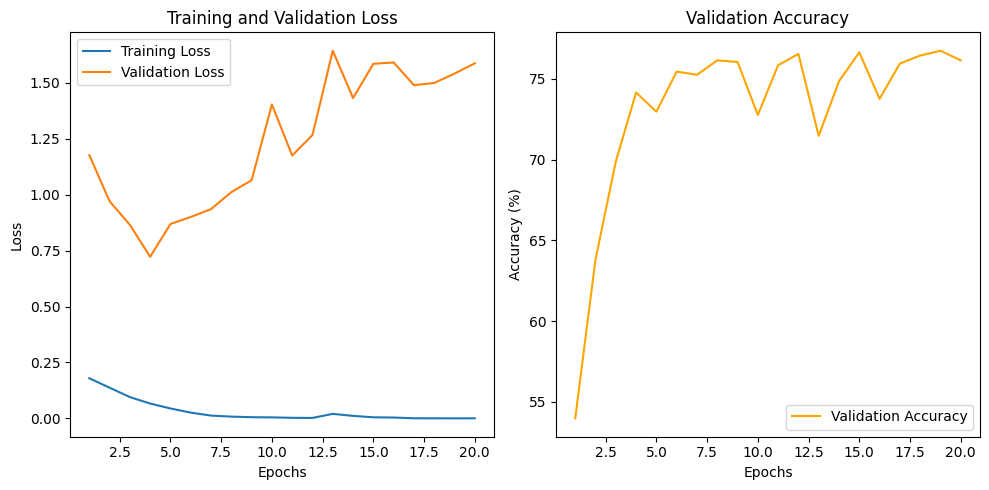

```python
# Plotting the training progress
plt.figure(figsize=(10, 5))

# Plot loss
plt.subplot(1, 2, 1)
plt.plot(range(1, epochs + 1), train_losses, label='Training Loss')
plt.plot(range(1, epochs + 1), val_losses, label='Validation Loss')
plt.xlabel('Epochs')
plt.ylabel('Loss')
plt.title('Training and Validation Loss')
plt.legend()

# Plot accuracy
plt.subplot(1, 2, 2)
plt.plot(range(1, epochs + 1), val_accuracies, label='Validation Accuracy', color='orange')
plt.xlabel('Epochs')
plt.ylabel('Accuracy (%)')
plt.title('Validation Accuracy')
plt.legend()

plt.tight_layout()
plt.show()
```

```python
# Evaluate the model on the test set
model.eval()  # Set model to evaluation mode
correct = 0
total = 0
with torch.no_grad():
    for images, bndboxes, labels in test_dataloader:
        images = images.to(device)
        labels = torch.tensor([labels_to_include.index(label) for label in labels]).to(device)

        # Get predictions
        outputs = model(images)
        _, predicted = torch.max(outputs.data, 1)

        # Total number of labels
        total += labels.size(0)

        # Total correct predictions
        correct += (predicted == labels).sum().item()

# Print test accuracy
print(f'Accuracy of the model on the {total} test images: {(correct / total) * 100:.2f}%')
```

```
Accuracy of the model on the 1007 test images: 76.66%
```

```python
torch.save(model.state_dict(), 'saved_models/5_hand_gesture_model.pth')

model_metadata = {
    'model_state_dict': model.state_dict(),
    'labels_to_include': labels_to_include,
    'input_size': (3, 224, 224),  # Example input size (channels, height, width)
    'output_size': len(labels_to_include)
}
torch.save(model_metadata, 'saved_models/5_hand_gesture_model_metadata.pth')
```